# Contexte

```python
pnns_group_1 = df_scaled["pnns_groups_1"].dropna().unique()
```

```
pour le groupe Milk and dairy products et la feature fat_100g
il y a 5 outliers
```

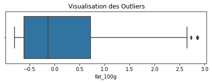

```
pour le groupe Milk and dairy products et la feature sugars_100g
il y a 22 outliers
```

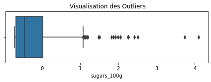

```
pour le groupe Milk and dairy products et la feature energy_100g
il y a 0 outliers
```

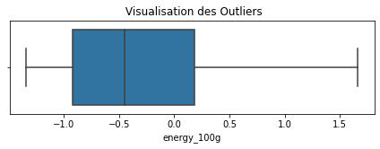

```
pour le groupe Milk and dairy products et la feature carbohydrates_100g
il y a 82 outliers
```

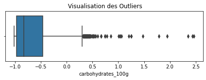

```
pour le groupe Milk and dairy products et la feature saturated-fat_100g
il y a 3 outliers
```

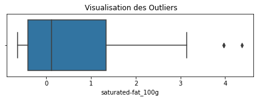

```
pour le groupe Milk and dairy products et la feature fiber_100g
il y a 237 outliers
```

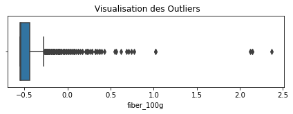

```
pour le groupe Milk and dairy products et la feature proteins_100g
il y a 8 outliers
```

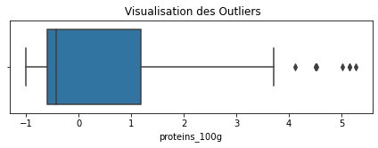

```
pour le groupe Milk and dairy products et la feature salt_100g
il y a 46 outliers
```

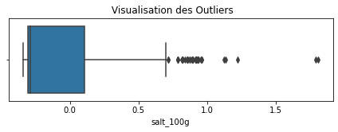

```
pour le groupe Beverages et la feature fat_100g
il y a 401 outliers
```

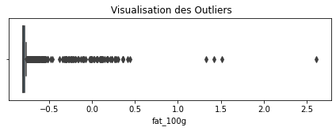

```
pour le groupe Beverages et la feature sugars_100g
il y a 256 outliers
```

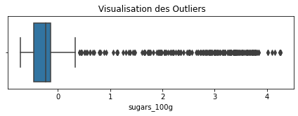

```
pour le groupe Beverages et la feature energy_100g
il y a 352 outliers
```

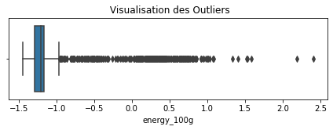

```
pour le groupe Beverages et la feature carbohydrates_100g
il y a 275 outliers
```

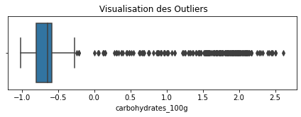

```
pour le groupe Beverages et la feature saturated-fat_100g
il y a 426 outliers
```

[60 more figures not shown]

```python
df_show_outliers=[]
for pnns in pnns_group_1:
    for col in numerical_value_100g:
        q1 = df_scaled[df_scaled['pnns_groups_1'] == pnns][col].quantile(.25)
        q3 = df_scaled[df_scaled['pnns_groups_1'] == pnns][col].quantile(.75)
        IQR = q3 - q1
        upper_boundary = q3 + (1.5 * IQR)
        lower_boundary = q1 - (1.5 * IQR)
        select = df_scaled[df_scaled['pnns_groups_1'] == pnns]
        outliers = select.loc[(select[col] > upper_boundary) | (
            select[col] < lower_boundary), [col]]
        print(
            f"pour le groupe {pnns} et la feature {col}")
        print(
            f"il y a {len(outliers)} outliers")
        df_show_outliers.append({'pnns': pnns, 'nutritionnelle': col,'outliers': len(outliers)})

        without_outliers = select.loc[(select[col] < upper_boundary) | (
            select[col] > lower_boundary), [col]]
        df_outlier = pd.DataFrame(without_outliers, columns=df_scaled.columns)
        plt.subplot(212)
        sns.boxplot(df_outlier[col])
        plt.title(" Visualisation des Outliers")
        plt.tight_layout()
        plt.show()
```

```python
df_show_outliers = pd.DataFrame(df_show_outliers).reset_index(drop=True)
df_show_outliers.sort_values(by='outliers', ascending=False)
```

|  | pnns | nutritionnelle | outliers |
| --- | --- | --- | --- |
| 57 | Cereals and potatoes | sugars_100g | 753 |
| 15 | Beverages | salt_100g | 637 |
| 19 | Sugary snacks | carbohydrates_100g | 457 |
| 12 | Beverages | saturated-fat_100g | 426 |
| 60 | Cereals and potatoes | saturated-fat_100g | 407 |
| 8 | Beverages | fat_100g | 401 |
| 43 | Fish Meat Eggs | carbohydrates_100g | 398 |
| 21 | Sugary snacks | fiber_100g | 397 |
| 66 | Fruits and vegetables | energy_100g | 391 |
| 41 | Fish Meat Eggs | sugars_100g | 374 |
| 10 | Beverages | energy_100g | 352 |
| 64 | Fruits and vegetables | fat_100g | 351 |
| 58 | Cereals and potatoes | energy_100g | 348 |
| 56 | Cereals and potatoes | fat_100g | 341 |
| 14 | Beverages | proteins_100g | 304 |
| 47 | Fish Meat Eggs | salt_100g | 300 |
| 30 | Fat and sauces | proteins_100g | 296 |
| 28 | Fat and sauces | saturated-fat_100g | 278 |
| 68 | Fruits and vegetables | saturated-fat_100g | 276 |
| 11 | Beverages | carbohydrates_100g | 275 |
| 67 | Fruits and vegetables | carbohydrates_100g | 262 |
| 9 | Beverages | sugars_100g | 256 |
| 69 | Fruits and vegetables | fiber_100g | 240 |
| 5 | Milk and dairy products | fiber_100g | 237 |
| 70 | Fruits and vegetables | proteins_100g | 227 |
| 36 | Composite foods | saturated-fat_100g | 220 |
| 25 | Fat and sauces | sugars_100g | 210 |
| 65 | Fruits and vegetables | sugars_100g | 206 |
| 27 | Fat and sauces | carbohydrates_100g | 197 |
| 37 | Composite foods | fiber_100g | 176 |
| 50 | Salty snacks | energy_100g | 174 |
| 31 | Fat and sauces | salt_100g | 173 |
| 51 | Salty snacks | carbohydrates_100g | 173 |
| 45 | Fish Meat Eggs | fiber_100g | 169 |
| 61 | Cereals and potatoes | fiber_100g | 169 |
| 33 | Composite foods | sugars_100g | 161 |
| 39 | Composite foods | salt_100g | 157 |
| 17 | Sugary snacks | sugars_100g | 157 |
| 13 | Beverages | fiber_100g | 150 |
| 62 | Cereals and potatoes | proteins_100g | 147 |
| 44 | Fish Meat Eggs | saturated-fat_100g | 143 |
| 52 | Salty snacks | saturated-fat_100g | 143 |
| 18 | Sugary snacks | energy_100g | 135 |
| 42 | Fish Meat Eggs | energy_100g | 129 |
| 38 | Composite foods | proteins_100g | 124 |
| 35 | Composite foods | carbohydrates_100g | 121 |
| 32 | Composite foods | fat_100g | 115 |
| 22 | Sugary snacks | proteins_100g | 109 |
| 49 | Salty snacks | sugars_100g | 104 |
| 71 | Fruits and vegetables | salt_100g | 97 |
| 59 | Cereals and potatoes | carbohydrates_100g | 93 |
| 54 | Salty snacks | proteins_100g | 92 |
| 53 | Salty snacks | fiber_100g | 88 |
| 48 | Salty snacks | fat_100g | 85 |
| 3 | Milk and dairy products | carbohydrates_100g | 82 |
| 23 | Sugary snacks | salt_100g | 70 |
| 46 | Fish Meat Eggs | proteins_100g | 67 |
| 34 | Composite foods | energy_100g | 58 |
| 63 | Cereals and potatoes | salt_100g | 57 |
| 40 | Fish Meat Eggs | fat_100g | 56 |
| 55 | Salty snacks | salt_100g | 50 |
| 7 | Milk and dairy products | salt_100g | 46 |
| 29 | Fat and sauces | fiber_100g | 43 |
| 1 | Milk and dairy products | sugars_100g | 22 |
| 20 | Sugary snacks | saturated-fat_100g | 8 |
| 6 | Milk and dairy products | proteins_100g | 8 |
| 0 | Milk and dairy products | fat_100g | 5 |
| 16 | Sugary snacks | fat_100g | 4 |
| 4 | Milk and dairy products | saturated-fat_100g | 3 |
| 26 | Fat and sauces | energy_100g | 0 |
| 2 | Milk and dairy products | energy_100g | 0 |
| 24 | Fat and sauces | fat_100g | 0 |

Nous pouvons observer les données nutritionelles en fonction du Pnns Group, Nous pouvons en conclure le sucre et le pnn Céréales dans lequel il ya davantage de valeurs atypiques (non abbérantes).

# Imputation

## Feature 'fiber_100g '

Nous cette feature, nous allons considerer que l'absence de données signifie l'absence de fiber_100, nous remplacons donc par 0 avec un fillna(0)

```python
df_nutriscore['fiber_100g'] = df_nutriscore['fiber_100g'].fillna(0)
```

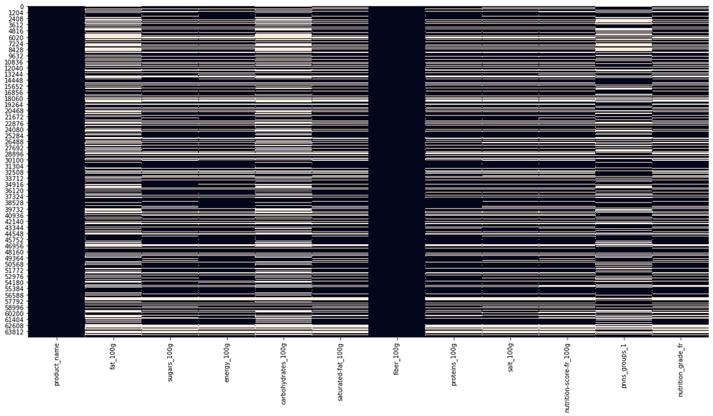

```python
#sisualisation des Nan avec seaborn et le heatmap
plt.figure(figsize=(20,10))
sns.heatmap(df_nutriscore.isna(), cbar=False)
```

## KNNImputer

Nous allons faire 2 imputations pour les valeurs nutritionnelles et comparer les moyennes et écart type avec notre df_nutriscore

```python
df_nutriscore.describe()
```

|  | fat_100g | sugars_100g | energy_100g | carbohydrates_100g | saturated-fat_100g | fiber_100g | proteins_100g | salt_100g | nutrition-score-fr_100g |
| --- | --- | --- | --- | --- | --- | --- | --- | --- | --- |
| count | 33478.000000 | 45736.000000 | 46978.000000 | 33144.000000 | 45651.000000 | 64989.000000 | 46885.000000 | 45764.000000 | 45103.000000 |
| mean | 13.161916 | 13.519979 | 1107.763522 | 27.722506 | 5.507449 | 1.313119 | 7.841506 | 0.995777 | 8.667428 |
| std | 16.403927 | 18.889725 | 767.329254 | 27.294064 | 8.593449 | 3.475545 | 7.802238 | 2.930120 | 9.005184 |
| min | 0.000000 | 0.000000 | 0.000000 | 0.000000 | 0.000000 | 0.000000 | 0.000000 | 0.000000 | -14.000000 |
| 25% | 1.400000 | 1.000000 | 430.000000 | 4.100000 | 0.300000 | 0.000000 | 1.900000 | 0.080000 | 1.000000 |
| 50% | 6.950000 | 4.200000 | 1028.000000 | 14.600000 | 2.000000 | 0.000000 | 6.100000 | 0.550000 | 8.000000 |
| 75% | 21.000000 | 18.000000 | 1651.000000 | 53.000000 | 7.500000 | 1.400000 | 11.000000 | 1.200000 | 15.000000 |
| max | 100.000000 | 100.000000 | 3774.000000 | 100.000000 | 100.000000 | 100.000000 | 100.000000 | 100.000000 | 40.000000 |

### Données nutritionelles

```python
# import the KNNimputer class
from sklearn.impute import KNNImputer
import time
```

```python
df_knn_all_row = df_nutriscore.copy()
```

```python
composants = df_knn_all_row[numerical_value_100g]
percent_missing = composants.isnull().sum() * 100 / len(composants)
missing_values = pd.DataFrame({'pourcentage_manquant': percent_missing})
missing_values.sort_values('pourcentage_manquant', inplace=True)
missing_values
```

|  | pourcentage_manquant |
| --- | --- |
| fiber_100g | 0.000000 |
| energy_100g | 27.713921 |
| proteins_100g | 27.857022 |
| salt_100g | 29.581929 |
| sugars_100g | 29.625013 |
| saturated-fat_100g | 29.755805 |
| fat_100g | 48.486667 |
| carbohydrates_100g | 49.000600 |

```python
tps1 = time.time()
X = df_knn_all_row[numerical_value_100g]
imputer = KNNImputer(n_neighbors=3) # N neighbors aléatoire
imputed = imputer.fit_transform(X)
tps2 = time.time()
print(tps2 - tps1, "secondes")
```

```
269.21559047698975 secondes
```

```python
df_imputed = pd.DataFrame(imputed, columns=X.columns)
df_imputed
```

|  | fat_100g | sugars_100g | energy_100g | carbohydrates_100g | saturated-fat_100g | fiber_100g | proteins_100g | salt_100g |
| --- | --- | --- | --- | --- | --- | --- | --- | --- |
| 0 | 8.333333 | 6.066667 | 818.666667 | 23.50 | 0.666667 | 0.0 | 6.5 | 0.886667 |
| 1 | 3.000000 | 8.500000 | 477.000000 | 8.50 | 2.000000 | 0.0 | 13.0 | 2.000000 |
| 2 | 8.333333 | 6.066667 | 818.666667 | 23.50 | 0.666667 | 0.0 | 6.5 | 0.886667 |
| 3 | 0.000000 | 9.700000 | 179.000000 | 10.00 | 0.000000 | 0.0 | 0.5 | 0.030000 |
| 4 | 0.800000 | 56.000000 | 1378.000000 | 76.00 | 0.100000 | 4.8 | 0.8 | 0.050038 |
| ... | ... | ... | ... | ... | ... | ... | ... | ... |
| 64984 | 8.333333 | 6.066667 | 818.666667 | 23.50 | 0.666667 | 0.0 | 6.5 | 0.886667 |
| 64985 | 8.333333 | 6.066667 | 818.666667 | 23.50 | 0.666667 | 0.0 | 6.5 | 0.886667 |
| 64986 | 0.500000 | 2.000000 | 983.000000 | 19.38 | 0.000000 | 54.0 | 3.0 | 0.177800 |
| 64987 | 8.333333 | 6.066667 | 818.666667 | 23.50 | 0.666667 | 0.0 | 6.5 | 0.886667 |
| 64988 | 0.000000 | 8.400000 | 184.000000 | 10.80 | 0.000000 | 0.0 | 0.0 | 0.040000 |

64989 rows × 8 columns

```python
#check KNN imputation worked
df_imputed.isna().sum()
```

```
fat_100g              0
sugars_100g           0
energy_100g           0
carbohydrates_100g    0
saturated-fat_100g    0
fiber_100g            0
proteins_100g         0
salt_100g             0
dtype: int64
```

```python
df_product_name = df_knn_all_row['product_name']
```

```python
df_knn_all_row = pd.concat([df_product_name, df_imputed], axis=1)
```

```python
df_knn_all_row.describe()
```

|  | fat_100g | sugars_100g | energy_100g | carbohydrates_100g | saturated-fat_100g | fiber_100g | proteins_100g | salt_100g |
| --- | --- | --- | --- | --- | --- | --- | --- | --- |
| count | 64989.000000 | 64989.000000 | 64989.000000 | 64989.000000 | 64989.000000 | 64989.000000 | 64989.000000 | 64989.000000 |
| mean | 11.780978 | 11.913556 | 1025.727146 | 27.633396 | 4.173991 | 1.313119 | 7.448868 | 0.944039 |
| std | 12.791154 | 16.546378 | 667.554381 | 21.548974 | 7.568075 | 3.475545 | 6.679092 | 2.464112 |
| min | 0.000000 | 0.000000 | 0.000000 | 0.000000 | 0.000000 | 0.000000 | 0.000000 | 0.000000 |
| 25% | 4.000000 | 2.100000 | 591.000000 | 12.000000 | 0.666667 | 0.000000 | 3.500000 | 0.120000 |
| 50% | 8.333333 | 6.066667 | 818.666667 | 23.500000 | 0.666667 | 0.000000 | 6.500000 | 0.886667 |
| 75% | 12.333333 | 12.000000 | 1473.000000 | 37.866667 | 4.400000 | 1.400000 | 8.370000 | 0.921970 |
| max | 100.000000 | 100.000000 | 3774.000000 | 100.000000 | 100.000000 | 100.000000 | 100.000000 | 100.000000 |

### Taux de Nan par row <50%

taux de Nan par row <50% de missing values

```python
df_knn_not_all_row = df_nutriscore.copy()
```

```python
# Count NaN in each row of a DataFrame
df_knn_not_all_row['% Nan'] = (df_knn_not_all_row.shape[1] -
                               df_knn_not_all_row.count(axis=1))*100/df_knn_not_all_row.shape[1]
```

```python
df_knn_not_all_row = df_knn_not_all_row.loc[df_knn_not_all_row['% Nan'] < 50]
```

```python
composants = df_knn_not_all_row[numerical_value_100g]
percent_missing = composants.isnull().sum() * 100 / len(composants)
missing_values = pd.DataFrame({'pourcentage_manquant': percent_missing})
missing_values.sort_values('pourcentage_manquant', inplace=True)
missing_values
```

|  | pourcentage_manquant |
| --- | --- |
| fiber_100g | 0.000000 |
| energy_100g | 0.193993 |
| proteins_100g | 0.213179 |
| salt_100g | 2.579462 |
| sugars_100g | 2.656207 |
| saturated-fat_100g | 2.696711 |
| fat_100g | 29.480483 |
| carbohydrates_100g | 29.518856 |

```python
tps1 = time.time()
X = df_knn_not_all_row[numerical_value_100g]
imputer = KNNImputer(n_neighbors=3) # N neighbors aléatoire
imputed = imputer.fit_transform(X)
tps2 = time.time()
print(tps2 - tps1, "secondes")
```

```
63.81848430633545 secondes
```

```python
df_imputed = pd.DataFrame(imputed, columns=X.columns)
df_imputed
```

|  | fat_100g | sugars_100g | energy_100g | carbohydrates_100g | saturated-fat_100g | fiber_100g | proteins_100g | salt_100g |
| --- | --- | --- | --- | --- | --- | --- | --- | --- |
| 0 | 3.0 | 8.500000 | 477.0 | 8.50 | 2.000000 | 0.0 | 13.0 | 2.000000 |
| 1 | 0.0 | 9.700000 | 179.0 | 10.00 | 0.000000 | 0.0 | 0.5 | 0.030000 |
| 2 | 0.8 | 56.000000 | 1378.0 | 76.00 | 0.100000 | 4.8 | 0.8 | 0.050038 |
| 3 | 14.3 | 34.300000 | 1636.0 | 59.10 | 6.200000 | 2.6 | 5.5 | 0.530000 |
| 4 | 22.0 | 18.766667 | 1800.0 | 52.00 | 18.300000 | 0.0 | 6.0 | 0.913333 |
| ... | ... | ... | ... | ... | ... | ... | ... | ... |
| 46904 | 41.6 | 1.000000 | 2401.6 | 36.60 | 7.766667 | 0.0 | 14.5 | 1.633333 |
| 46905 | 7.6 | 0.800000 | 621.0 | 13.30 | 2.300000 | 0.0 | 6.7 | 0.880000 |
| 46906 | 0.4 | 0.200000 | 1504.0 | 80.40 | 0.100000 | 1.0 | 6.7 | 0.013005 |
| 46907 | 0.5 | 2.000000 | 983.0 | 19.38 | 0.000000 | 54.0 | 3.0 | 0.177800 |
| 46908 | 0.0 | 8.400000 | 184.0 | 10.80 | 0.000000 | 0.0 | 0.0 | 0.040000 |

46909 rows × 8 columns

```python
#check KNN imputation worked
df_imputed.isna().sum()
```

```
fat_100g              0
sugars_100g           0
energy_100g           0
carbohydrates_100g    0
saturated-fat_100g    0
fiber_100g            0
proteins_100g         0
salt_100g             0
dtype: int64
```

```python
df_knn_not_all_row.reset_index(inplace=True)
```

```python
df_product_name = df_knn_not_all_row[['product_name','pnns_groups_1','nutrition_grade_fr']]
```

```python
df = pd.concat([df_product_name, df_imputed], axis=1)
```

```python
df.describe()
```

|  | fat_100g | sugars_100g | energy_100g | carbohydrates_100g | saturated-fat_100g | fiber_100g | proteins_100g | salt_100g |
| --- | --- | --- | --- | --- | --- | --- | --- | --- |
| count | 46909.000000 | 46909.000000 | 46909.000000 | 46909.000000 | 46909.000000 | 46909.000000 | 46909.000000 | 46909.000000 |
| mean | 12.474881 | 13.509040 | 1108.554828 | 27.275873 | 5.510056 | 1.818805 | 7.838918 | 1.002305 |
| std | 15.497559 | 18.863083 | 766.824167 | 26.419368 | 8.531838 | 3.976825 | 7.800604 | 2.906719 |
| min | 0.000000 | 0.000000 | 0.000000 | 0.000000 | 0.000000 | 0.000000 | 0.000000 | 0.000000 |
| 25% | 1.400000 | 1.000000 | 431.000000 | 4.600000 | 0.300000 | 0.000000 | 1.900000 | 0.080000 |
| 50% | 6.566667 | 4.250000 | 1029.000000 | 15.000000 | 2.000000 | 0.100000 | 6.100000 | 0.560000 |
| 75% | 20.000000 | 18.100000 | 1651.000000 | 51.800000 | 7.600000 | 2.300000 | 11.000000 | 1.210000 |
| max | 100.000000 | 100.000000 | 3774.000000 | 100.000000 | 100.000000 | 100.000000 | 100.000000 | 100.000000 |

### KNNImputer sur les données qualitatives

```python
df_cat_num = df.copy()
```

```python
df_cat = df[['product_name']]
```

```python
df_cat_num = pd.merge(df_cat_num,df_cat, on='product_name')
```

```python
df_dummy_pnns = df_cat_num.copy()
```

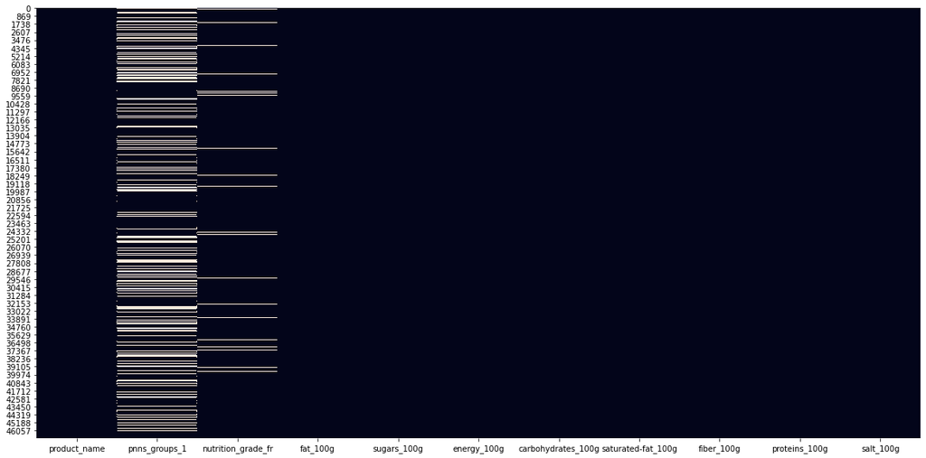

```python
#visualisation des Nan avec seaborn et le heatmap
plt.figure(figsize=(20,10))
sns.heatmap(df_dummy_pnns.isna(), cbar=False)
```

```python
df_dummy_pnns['nutrition_grade_fr'].nunique()
```

```
5
```

```python
cat_variables = df_dummy_pnns['pnns_groups_1']
cat_dummies = pd.get_dummies(cat_variables)
cat_dummies.head()
```

|  | Beverages | Cereals and potatoes | Composite foods | Fat and sauces | Fish Meat Eggs | Fruits and vegetables | Milk and dairy products | Salty snacks | Sugary snacks |
| --- | --- | --- | --- | --- | --- | --- | --- | --- | --- |
| 0 | 0 | 0 | 0 | 0 | 0 | 0 | 1 | 0 | 0 |
| 1 | 1 | 0 | 0 | 0 | 0 | 0 | 0 | 0 | 0 |
| 2 | 0 | 0 | 0 | 0 | 0 | 0 | 0 | 0 | 1 |
| 3 | 0 | 0 | 0 | 0 | 0 | 0 | 0 | 0 | 1 |
| 4 | 0 | 0 | 0 | 0 | 0 | 0 | 0 | 0 | 1 |

```python
df_dummy_pnns.drop(['product_name','pnns_groups_1', 'nutrition_grade_fr'],axis=1,inplace=True)
```

```python
df = pd.concat([df_dummy_pnns, cat_dummies], axis=1)
df.head()
```

|  | fat_100g | sugars_100g | energy_100g | carbohydrates_100g | saturated-fat_100g | fiber_100g | proteins_100g | salt_100g | Beverages | Cereals and potatoes | Composite foods | Fat and sauces | Fish Meat Eggs | Fruits and vegetables | Milk and dairy products | Salty snacks | Sugary snacks |
| --- | --- | --- | --- | --- | --- | --- | --- | --- | --- | --- | --- | --- | --- | --- | --- | --- | --- |
| 0 | 3.0 | 8.500000 | 477.0 | 8.5 | 2.0 | 0.0 | 13.0 | 2.000000 | 0 | 0 | 0 | 0 | 0 | 0 | 1 | 0 | 0 |
| 1 | 0.0 | 9.700000 | 179.0 | 10.0 | 0.0 | 0.0 | 0.5 | 0.030000 | 1 | 0 | 0 | 0 | 0 | 0 | 0 | 0 | 0 |
| 2 | 0.8 | 56.000000 | 1378.0 | 76.0 | 0.1 | 4.8 | 0.8 | 0.050038 | 0 | 0 | 0 | 0 | 0 | 0 | 0 | 0 | 1 |
| 3 | 14.3 | 34.300000 | 1636.0 | 59.1 | 6.2 | 2.6 | 5.5 | 0.530000 | 0 | 0 | 0 | 0 | 0 | 0 | 0 | 0 | 1 |
| 4 | 22.0 | 18.766667 | 1800.0 | 52.0 | 18.3 | 0.0 | 6.0 | 0.913333 | 0 | 0 | 0 | 0 | 0 | 0 | 0 | 0 | 1 |

```python
df = pd.DataFrame(scaler.fit_transform(df), columns = df.columns)
df.head()
```

|  | fat_100g | sugars_100g | energy_100g | carbohydrates_100g | saturated-fat_100g | fiber_100g | proteins_100g | salt_100g | Beverages | Cereals and potatoes | Composite foods | Fat and sauces | Fish Meat Eggs | Fruits and vegetables | Milk and dairy products | Salty snacks | Sugary snacks |
| --- | --- | --- | --- | --- | --- | --- | --- | --- | --- | --- | --- | --- | --- | --- | --- | --- | --- |
| 0 | -0.611385 | -0.265550 | -0.823607 | -0.710694 | -0.411411 | -0.457356 | 0.661633 | 0.343241 | -0.287052 | -0.315311 | -0.333969 | -0.217991 | -0.30281 | -0.237115 | 3.043773 | -0.178978 | -0.410900 |
| 1 | -0.804966 | -0.201933 | -1.212227 | -0.653916 | -0.645830 | -0.457356 | -0.940824 | -0.334506 | 3.483690 | -0.315311 | -0.333969 | -0.217991 | -0.30281 | -0.237115 | -0.328540 | -0.178978 | -0.410900 |
| 2 | -0.753345 | 2.252623 | 0.351382 | 1.844278 | -0.634109 | 0.749650 | -0.902365 | -0.327612 | -0.287052 | -0.315311 | -0.333969 | -0.217991 | -0.30281 | -0.237115 | -0.328540 | -0.178978 | 2.433684 |
| 3 | 0.117769 | 1.102215 | 0.687838 | 1.204588 | 0.080868 | 0.196439 | -0.299841 | -0.162489 | -0.287052 | -0.315311 | -0.333969 | -0.217991 | -0.30281 | -0.237115 | -0.328540 | -0.178978 | 2.433684 |
| 4 | 0.614627 | 0.278729 | 0.901709 | 0.935843 | 1.499100 | -0.457356 | -0.235743 | -0.030609 | -0.287052 | -0.315311 | -0.333969 | -0.217991 | -0.30281 | -0.237115 | -0.328540 | -0.178978 | 2.433684 |

```python
imputer = KNNImputer(n_neighbors=3)
df = pd.DataFrame(imputer.fit_transform(df),columns = df.columns)
```

```python
# vérification de l'imputation
df.isna().sum()
```

```
fat_100g                   0
sugars_100g                0
energy_100g                0
carbohydrates_100g         0
saturated-fat_100g         0
fiber_100g                 0
proteins_100g              0
salt_100g                  0
Beverages                  0
Cereals and potatoes       0
Composite foods            0
Fat and sauces             0
Fish Meat Eggs             0
Fruits and vegetables      0
Milk and dairy products    0
Salty snacks               0
Sugary snacks              0
dtype: int64
```

```python
# drop feature axis 1 n'appartenant pas à pnns group avant idmax
df.drop(['fat_100g', 'sugars_100g', 'energy_100g', 'carbohydrates_100g',
         'saturated-fat_100g', 'fiber_100g', 'proteins_100g', 'salt_100g'], axis=1, inplace=True)
```

```python
# .from_dummies() returns a data frame
new_df = df.idxmax(axis=1)

#pd.dataframe
new_df = pd.DataFrame(new_df)
```

```python
#concat
df = pd.concat([df_dummy_pnns , new_df], axis=1)
```

```python
df_cat_num = df_cat_num[['product_name','nutrition_grade_fr']]
```

```python
#concat
df = pd.concat([df,df_cat_num], axis=1)
```

```python
# rename
df = df.rename(columns={0: 'pnns_groups_1'})
```

```python
df.head(3)
```

|  | fat_100g | sugars_100g | energy_100g | carbohydrates_100g | saturated-fat_100g | fiber_100g | proteins_100g | salt_100g | pnns_groups_1 | product_name | nutrition_grade_fr |
| --- | --- | --- | --- | --- | --- | --- | --- | --- | --- | --- | --- |
| 0 | 3.0 | 8.5 | 477.0 | 8.5 | 2.0 | 0.0 | 13.0 | 2.000000 | Milk and dairy products | Bridelight 3% Les carrés fondants goût Emmental | C |
| 1 | 0.0 | 9.7 | 179.0 | 10.0 | 0.0 | 0.0 | 0.5 | 0.030000 | Beverages | 100 % Pur Jus Pomme | C |
| 2 | 0.8 | 56.0 | 1378.0 | 76.0 | 0.1 | 4.8 | 0.8 | 0.050038 | Sugary snacks | 18 marrons glacés | C |

```python
df.isna().sum()
```

```
fat_100g                 0
sugars_100g              0
energy_100g              0
carbohydrates_100g       0
saturated-fat_100g       0
fiber_100g               0
proteins_100g            0
salt_100g                0
pnns_groups_1            0
product_name             0
nutrition_grade_fr    1844
dtype: int64
```

```python
df.dropna(axis=0,inplace=True)
```

```python
df.to_csv('openfoodfacts.csv', index=False, header=True)
```